# tarea2

linares_german

23/9/2021

```r
library(tidyverse)
library(tidyselect)
library(tidyr)
library(dplyr)
library(grid)
library(gridExtra)
```

# Ejercicio 1. Simulando variables aleatorias discretas.

#### Calcula la media y la varianza teóricas de esta variable.

```r
# Aquí calculamos la media y la varianza siguiendo la forma teórica
x1 <- c(0, 1, 2, 3)
px1 <- c(64/125, 48/125, 12/125, 1/125)

prod = x1 * px1
print(prod)
```

```
## [1] 0.000 0.384 0.192 0.024
```

```r
mean = sum(prod)
print(mean)
```

```
## [1] 0.6
```

```r
variance = sum((x1 - sum(x1 * px1))^2 * px1)
print(variance)
```

```
## [1] 0.48
```

```r
std_dev = sqrt(variance)
print(std_dev)
```

```
## [1] 0.6928203
```

### Apartado 2: Combina sample con replicate para simular cien mil muestras de tamaño 10 de esta variable X1. Estudia la distribución de las medias muestrales como hemos hecho en ejemplos previos, ilustrando con gráficas la distribución de esas medias muestrales. Cambia después el tamaño de la muestra a 30 y repite el análisis.

```r
k = 100000
n = 10
medias_muestrales = replicate(k, {
  muestra = sample(x1, n, replace = TRUE, prob = px1)
  mean(muestra)
})
head(medias_muestrales, 10)
```

```
##  [1] 0.7 0.7 0.7 0.6 0.9 0.7 0.8 0.5 0.7 0.8
```

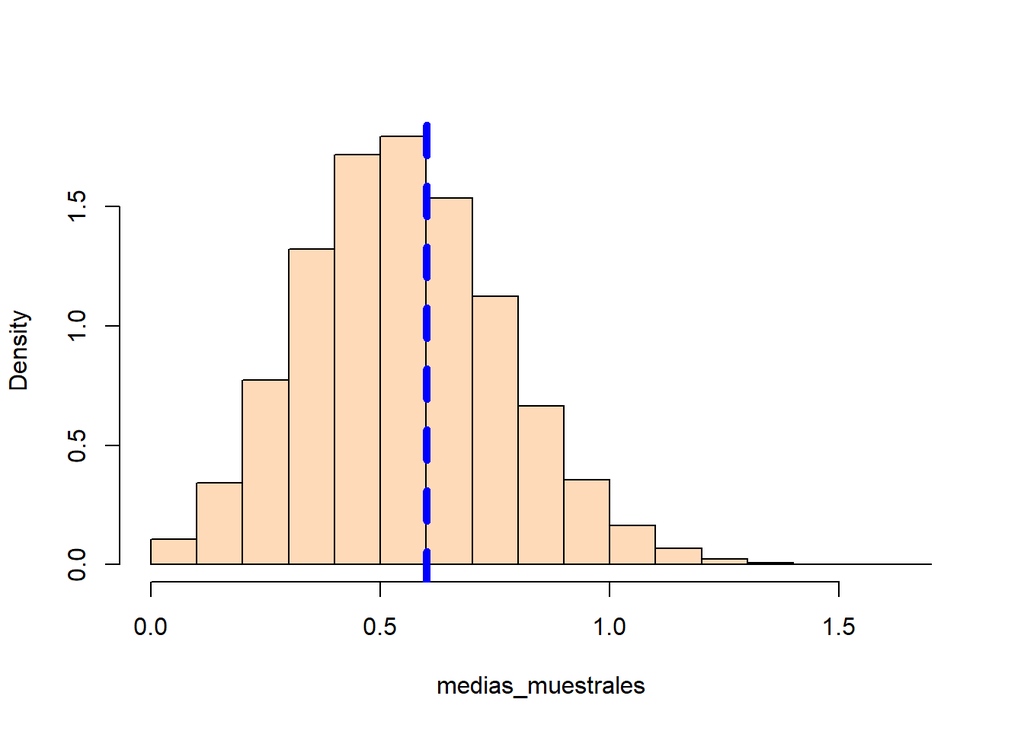

```r
# Representación gráfica de la distribuciónn de las medias muestrales con R básico
hist(medias_muestrales, breaks = 20, main="",
     col="peachpuff", probability = TRUE)
abline(v = mean(medias_muestrales), lty=2, lwd=5, col="blue")
```

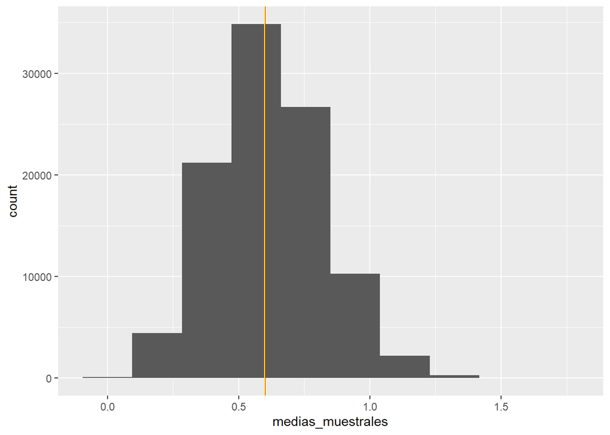

```r
# Aquí representados con ggplot

medias_muestrales = replicate(k, {
  muestra = sample(x1, n, replace = TRUE, prob = px1)
  mean(muestra)
})
medias_muestrales = data.frame(medias_muestrales)
ggplot(medias_muestrales) +
  geom_histogram(aes(medias_muestrales), bins = 10) +
  geom_vline(aes(xintercept = mean),color = "red") +
  geom_vline(aes(xintercept = mean(medias_muestrales)),color = "yellow")
```

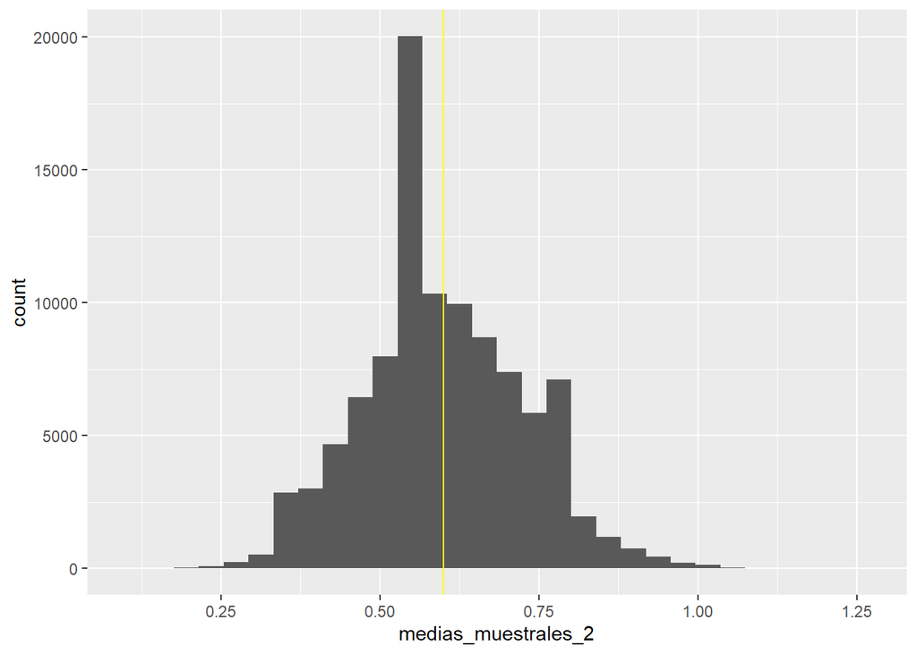

```r
k = 100000
n = 30
medias_muestrales_2 = replicate(k, {
  muestra = sample(x1, n, replace = TRUE, prob = px1)
  mean(muestra)
})
medias_muestrales_2 = data.frame(medias_muestrales_2)
ggplot(medias_muestrales_2) +
  geom_histogram(aes(medias_muestrales_2)) +
  geom_vline(aes(xintercept = mean),color = "red") +
  geom_vline(aes(xintercept = mean(medias_muestrales_2)),color = "yellow")
```

```r
# Creamos los vectores de probabilidad
x1 <- c(64/125, 48/125, 12/125, 1/125)
x2 <- c(1/2, 1/4, 1/4)
```

```r
# Buscamos las probabilidades de los posibles eventos
p0 <- x2[1]*x1[1]
p1 <- x2[2]*x1[1] + x2[1]*x1[2]
p2 <- x2[3]*x1[1] + x2[2]*x1[2] + x2[1]*x1[3]
p3 <- x2[1]*x1[4] + x2[2]*x1[3] + x2[3]*x1[2]
p4 <- x2[2]*x1[4] + x2[3]*x1[3]
p5 <- x2[3]*x1[4]
```

```r
# Creamos la tabla
resultados = matrix(c(p0, p1, p2, p3, p4, p5), nrow = 1)
colnames(resultados) =  c("Z0", "Z1", "Z2", "Z3", "Z4", "Z5")
resultados
```

```
##         Z0   Z1    Z2    Z3    Z4    Z5
## [1,] 0.256 0.32 0.272 0.124 0.026 0.002
```

### Apartado 4: Calcula la media teórica de la suma X1 + X2. Después usa sample y replicate para simular cien mil valores de esta variable suma. Calcula la media de esos valores. Advertencia: no es el mismo tipo de análisis que hemos hecho en el segundo apartado.

```r
prob_suma = resultados
sumas = c(0,1,2,3,4,5)
#Media teórica de la suma
(media_suma_teorica = sum(sumas*prob_suma))
```

```
## [1] 1.35
```

```r
valores = replicate(sample(x = sumas, prob = prob_suma, size = 1), n = 100000)
(media_suma_sample = mean(valores))
```

```
## [1] 1.35079
```

# Ejercicio 2. Datos Limpios

```r
test_results = read_csv("data/testResults.csv")
head(test_results)
```

```
## # A tibble: 6 x 9
##   name       id gender_age test_number week1 week2 week3 week4 week5
##   <chr>   <dbl> <chr>            <dbl> <dbl> <dbl> <dbl> <dbl> <dbl>
## 1 Jacob     108 m_20                 1     8     5     7     5     6
## 2 Jacob     108 m_20                 2     2     2     4     0     3
## 3 Michael   490 m_19                 1    10     0     5     4     0
## 4 Michael   490 m_19                 2     9    10     8    10     9
## 5 Matthew   424 m_18                 1     6     0     0     1    10
## 6 Matthew   424 m_18                 2     3     4     2     5     8
```

```r
# gender_age debería separarse en dos columnas, género y edad para cumplir los requisitos de tidy data
# adicionalmente, las columnas de week# se pueden pivotar para conseguir una única columna con el número de semana
```

```r
# separamos edad y género
test_results_tidy <- test_results %>%
  separate(gender_age, c("Gender", "Age"), sep = "_", convert = TRUE)
```

```r
#agrupamos las columnas de week
test_results_tidy <- test_results_tidy %>%
  pivot_longer(week1:week5, names_to="Week", names_prefix = "week")
test_results_tidy
```

```
## # A tibble: 1,000 x 7
##    name     id Gender   Age test_number Week  value
##    <chr> <dbl> <chr>  <int>       <dbl> <chr> <dbl>
##  1 Jacob   108 m         20           1 1         8
##  2 Jacob   108 m         20           1 2         5
##  3 Jacob   108 m         20           1 3         7
##  4 Jacob   108 m         20           1 4         5
##  5 Jacob   108 m         20           1 5         6
##  6 Jacob   108 m         20           2 1         2
##  7 Jacob   108 m         20           2 2         2
##  8 Jacob   108 m         20           2 3         4
##  9 Jacob   108 m         20           2 4         0
## 10 Jacob   108 m         20           2 5         3
## # ... with 990 more rows
```